# exer1

yanting

2023-05-03

```r
library(tidyverse)
library(dplyr)
library(showtext)
showtext_auto()
library(lme4)
library(lmerTest)
```

```r
library(ggplot2)
library(poolr)
library(ggrepel)
```

# load a .csv file

This is to create a function that help us load in .csv data files. col_names defines the columns of the data frame. Among them we want line_num and word_form are categorical variables.

```r
load_data <- function(file) {
  logprob <- read_delim(file, locale=locale(encoding="UTF-8"),
                       col_names = c("target_word",
                                     "concept",
                                     "word_form",
                                     "target_word_logprob",
                                     "disj_logprob",
                                     "line_num"))
  logprob$line_num <- as.factor(logprob$line_num)
  logprob$word_form <- as.factor(logprob$word_form)
  return(logprob)
}
```

This is to load the .csv data file from data/ folder.

```r
data <- load_data("/Users/yanting/Documents/UCI/2023_Spring/Experiment_methods/lsci253M/data/prob_oldpairfilled2-200.csv")
```

# perform some analysis on the data (e.g., mean; sd)

This is to create a new data frame that contains the average target word surprisal and average concept surprisal for each target word.

```r
means = data %>% group_by(target_word, concept, word_form) %>% summarize(concept_surprisal=-mean(disj_logprob), target_word_surprisal=-mean(target_word_logprob)) %>% ungroup()
```

This is to create a new data frame where each row contains the 1) concept, 2) average concept surprisal when the concept appears as the long form, and 3) average concept surprisal when the concept appears as the short form

```r
t_test_data <- means %>% select(-target_word, -target_word_surprisal) %>% spread(word_form, concept_surprisal)
```

# visualize the data

This is to create the right data frame for plotting the data

```r
diffline <- t_test_data %>%
  mutate(diff = long - short) %>% mutate(above_zero = if_else(diff > 0, "above 0", "below 0")) %>% mutate(long_sur = long) %>%
  group_by(concept) %>%
  pivot_longer(cols = c("long", "short"), names_to = "form", values_to = "surprisal")  %>% arrange(long_sur)
```

This is to plot the average estimated surprisal of both long and short form for each of the 100 concepts. For each concept, there is a solid circle representing the long form and a hollow circle representing the short form. Each pair of circles are connected by a solid line showing the difference between the surprisal of the two forms (long - short). If the difference is negative, the line is colored red. Otherwise it is colored blue.

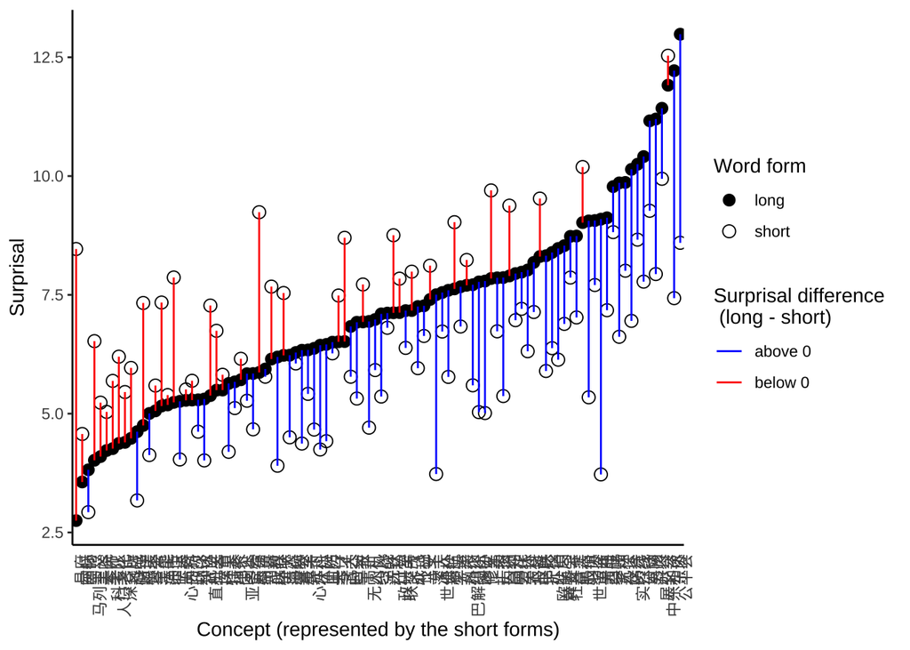

```r
diffline %>%
  ggplot(aes(x = reorder(concept, long_sur, mean), y = surprisal, group = concept)) +
  geom_point(aes(shape = form), size = 3) +
  geom_line(aes(color = above_zero), size = 0.5) +
  scale_shape_manual(values = c(16, 1)) +
  scale_color_manual(values = c("blue", "red")) +
  theme_classic() +
  labs(y = "Surprisal", x = 'Concept (represented by the short forms)', color = "Surprisal difference \n (long - short)", shape = "Word form") +
  theme(axis.ticks.x = element_blank(), axis.text.x = element_text(angle = 90, hjust = 1)) +
  scale_x_discrete(labels = function(x) diffline$concept[match(x, diffline$concept)])
```

# provide text to describe the data

As we can see from the plot, among the 100 concepts sampled, 63 have a blue line, indicating that the majority of the long forms tend to have higher surprisal than their short counterpart, which means that the long forms tend to contain more information in general.